# Burlington Fire Department Incidents & Response Times, 2018 - 2019

Clay Chisholm, Ethan Lauricella & Lucía Carrera

10/17/2021

## Introduction

The data set we are analyzing is based on data from the Burlington Fire Department. This data includes information on incident types and response times from Aug 1, 2018, through November 30, 2019. Data was pulled from the fire department RMS database. There is no sample bias as the data is strictly incident responses of the fire department. This data is an observational study to see the time taken from call to response of the fire department and locations of incidents. The only bias that is seen is possibility in rounding times to the nearest minute, but this is understandable and would not affect the results, as long as one is informed about this occurrence.

We believe this data could be very interesting to understand the reasons for which the population of Burlington most frequently call the fire department, as well as, the efficiency and speed that this department has. Due to the city having a large population of students, we are also intrigued to see if the large influx of college students during the fall and spring semester affect the data. Another factor we believe could have an effect on our data is the winter season, as the state of Vermont is famous for being its glacial temperatures in the months of December through March. This factor could drastically change the reasons to why the fire department was called.

The goal of our project is to provide insight on future resources allocated by the Burlington fire department.

```r
knitr::opts_chunk$set(echo = TRUE)
```

## Data Setup & Cleaning

Apart from the typical data setup, involving the loading of libraries and the csv, we had to do some “cleaning” of the data. This was done to be able to use this data set with greater ease.

The most important part in our “cleaning” process, was to change the names of our variables, as they were very lengthy and incomprehensible. We also modified the geopoint column by separating and creating two new variables, Longitude and Latitude. The reasoning was to be able to use Leaflet to plot coordinates.

```r
# Loading of packages we will use for our project
library(tidyverse)
library(lubridate)
library(leaflet)
library(gridExtra)

# Loading of the data frame fire to use
fire <- read.csv("O_fire_new.csv", na.strings = '', stringsAsFactors = TRUE)

# Modification of variable names
names(fire)[3] <- "Inc_num"            # Incident number
names(fire)[4] <- "Inc_des"            # Incident description
names(fire)[5] <- "Alm_dt"             # Alarm date and time
names(fire)[6] <- "Dis_dt"             # Dispatch date and time
names(fire)[7] <- "Not_dt"             # Dispatch Notified Date and Time
names(fire)[8] <- "Roll_dt"            # Unit responding Date and Time
names(fire)[9] <- "Arv_dt"             # Arrival Date and Time
names(fire)[10] <- "Ins_dt"            # In Service Time

# Additional latitude and longitude columns
fire <- fire %>%
  mutate(geopoint2 = str_sub(geopoint, 1,-1)) %>%
  separate(geopoint2, into = c('Lat', 'Long'), sep = ',')%>%
  mutate(Long = as.numeric(Long), Lat =as.numeric(Lat))
```

## Data Analysis

### Number of Calls per Hour

The first graph we wanted to map out is the time of calls to see at what were the most “popular” times to call the fire department. To do so, we plotted the following bar graph. For the graph to be presentable, we did additional data cleaning, here we decided to extract the exact time of calls including the columns with only the date, month, weekday and hour. We also modified the Hour column so it scales from 1 to 24, instead of 0 to 23. This was done because we believe it is more intuitive.

We believe that the reason this graph has a bell shape is because the typical work or school day is between these hours. Meaning more people are awake, active and alert. It is known that the more activity, the more chances of an accident to happen. Also, if for example a cat gets stuck in a tree, there are more chances that someone sees them and calls the fire department, because these hours also coincide with the Sun’s schedule.

```r
#  Further "cleaning"
alarm <- fire %>%
  # modification of variables for the graphs
  mutate(Call = mdy_hm(Alm_dt),
         Date = date(Call),
         Mon = month(Call, label = TRUE),
         Weekday = wday(Call, label = TRUE),
         Hour = as.ordered(hour(Call)+1),
         HourNum = hour(Call)+1) %>%
  # modification of variables for the summary statistics
  mutate(MonNum = month(Call, label = FALSE),
         WeekdayNum = wday(Call, label = FALSE))

# summary statistics
summary(alarm$HourNum)
```

```
##    Min. 1st Qu.  Median    Mean 3rd Qu.    Max.
##     1.0     8.0    12.0    12.5    17.0    24.0
```

```r
perHour <- alarm %>%
  group_by(Hour) %>%
  summarise(count = n())
stats <- perHour %>%
  summarise(maxCalls = max(count),
            minCalls = min(count))
left_join(stats, perHour, by = c( 'maxCalls' = 'count')) %>% select(Hour, maxCalls)
```

```
## # A tibble: 1 x 2
##   Hour  maxCalls
##   <ord>    <int>
## 1 12         644
```

```r
left_join(stats, perHour, by = c('minCalls' = 'count')) %>% select(Hour, minCalls)
```

```
## # A tibble: 1 x 2
##   Hour  minCalls
##   <ord>    <int>
## 1 1          178
```

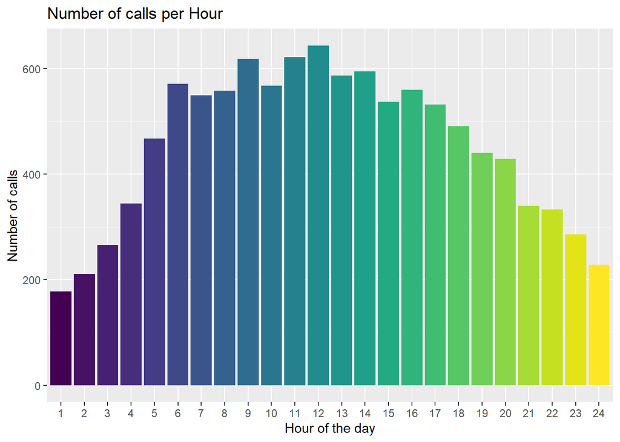

```r
# histogram of number of calls by hour
ggplot(data = alarm,
       mapping = aes(x= Hour, fill = Hour)) +
  geom_bar( binwidth = 1, bins = 24) +
  labs(title = "Number of calls per Hour", y='Number of calls', x='Hour of the day') +
  guides(fill = 'none')
```

### Location of Calls

The graph below is a leaflet/GeoPoint graph used to represent where the calls are located in Burlington. The calls are located in Burlington, but there are some calls located on the edge of Colchester and South Burlington. There is also an outlier, located all the way out near Montpelier. There is a very small amount of outliers (>.1%) which could be from technical error from the department.

```r
#  using dplyr and leaflet we filtered how much zoom and what part of the world the map would show
m <- leaflet() %>%
  addTiles() %>%
  setView(lat = 44.475, lng = -73.212, zoom = 12)
# Using leaflet, we made a map showing circles on the location of each incident.
m  %>% addCircles(lng = fire$Long, lat = fire$Lat)
```

[interactive chart not shown]

### Unit Response Count

This histogram represents the amount of time each unit is called upon to respond to an emergency. A “Unit” within the fire department may dedicate to special tasks such as EMS or special rescue. Examples: Fire Engine s.t. E1 = Engine 1 L: Ladder Truck T: Tender C: Car A: Ambulance ERA: Emergency Room Ambulance. The most popular unit called upon was E1, we believe this is because this unit in particular is the “go-to” for most distress calls. Seeing that the most common call is an EMS call, it is safe to assume that e1 is sent to respond to EMS calls.

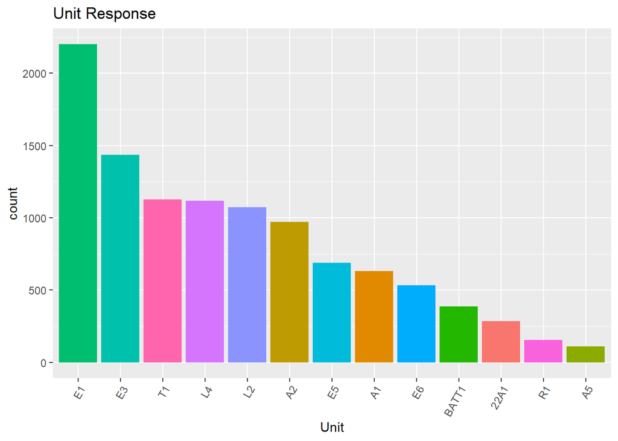

```r
#  new data frame to group data by unit, get the how many calls they responded to,
# arranged in descending according to count and only show unit and count
f2 <- fire %>%
  group_by(Unit) %>%
  summarize(count = n()) %>%
  arrange(desc(count)) %>%
  select(Unit = Unit, count = count) %>%
  filter(count > 90)

# bar graph of number of calls each unit responded to
ggplot(data = fire,
  mapping = aes(x = Unit, fill = Unit) ) +
  geom_bar() +
  theme(axis.text.x = element_text(hjust=1, angle = 60)) +
  scale_x_discrete(limits = f2$Unit) +
  guides(fill=FALSE) +
  labs(title = "Unit Response ")
```

### Type of incident description

```r
# Amount of calls with the Incident Description being 'EMS call'
  fire %>%
  group_by(Inc_des) %>%
  summarize(count = n()) %>%
  filter(Inc_des == 'EMS call')
```

```
## # A tibble: 1 x 2
##   Inc_des  count
##   <fct>    <int>
## 1 EMS call  6551
```

```r
#table for incident descriptions
incident <- fire %>%
  group_by(Inc_des) %>%
  summarize(count = n()) %>%
  arrange(count) %>%
  filter(count > 90, Inc_des != 'EMS call') %>%
  tail(10)

#descending incident table, made to match the graph
desc_incident <- fire %>%
  group_by(Inc_des) %>%
  summarize(count = n()) %>%
  arrange(desc(count)) %>%
  filter(count > 90, Inc_des != 'EMS call') %>%
  tail(10)

#print table
desc_incident
```

```
## # A tibble: 10 x 2
##    Inc_des                                                                 count
##    <fct>                                                                   <int>
##  1 EMS call where injured party has been transported by a non-fire servic~   590
##  2 Smoke detector activation (no fire), unintentional                        550
##  3 Smoke detector activation due to malfunction                              396
##  4 Assist invalid                                                            350
##  5 Good intent call, other                                                   222
##  6 Alarm system activation due to malfunction                                183
##  7 Motor vehicle accident with no injuries                                   146
##  8 No incident found on arrival at dispatch address                          118
##  9 Motor vehicle accident with injuries                                      104
## 10 Alarm system activation (no fire), unintentional                           91
```

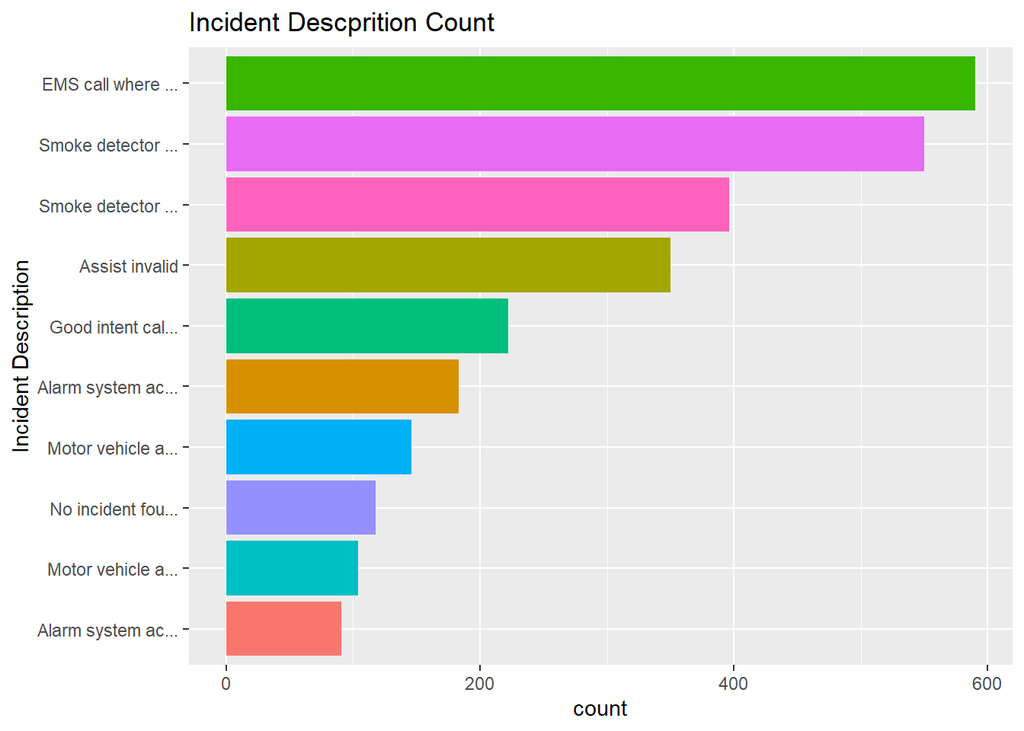

```r
#ggplot graph
ggplot(data = fire,
       mapping = aes(x = Inc_des, fill = Inc_des)) +
  geom_bar() +  # We have an issue here
  scale_x_discrete(limits = incident$Inc_des, label=function(x) stringr::str_trunc(x,18)) +
  labs(title = "Incident Descprition Count") +
  xlab("Incident Description") +
  guides(fill = 'none') +
  coord_flip()
```

### Month by shifts

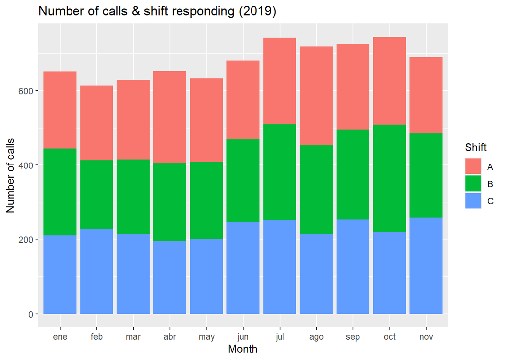

```r
# filter data into new dataframe to remove NAs from Shift and Dispatch (date and time)
shift_time <- fire %>%
  filter(!is.na(Shift)) %>%
  filter(!is.na(Dis_dt)) %>%
  filter(Shift != "N") %>%
  filter(Shift != "D") %>%

  # date and time separated so we can clearly see month, date, hour, weekday, etc
  mutate(Call = mdy_hm(Dis_dt),
         Weekday = wday(Call, label = TRUE),
         Mon = month(Call, label = TRUE),
         Date = date(Call),
         Hour = hour(Call),
         Year = year(Call)) %>%
  filter(Year != "2018")

# bar graph of Month with shift as fill
ggplot(data = shift_time,
       mapping = aes(x= Mon, fill = Shift))+
  geom_bar() +
  labs(title = "Number of calls & shift responding (2019)", y='Number of calls', x='Month')
```

### Amount of time at each incident

This plot shows the time spent at each incident in minutes. Most incidents only take about 20 minutes at the site. There is some cases where the shift is needed at a site for a long time. Most incidents are EMS calls, thus this makes sense as they most likely arrive at the scene and call for an ambulance to deliver the patient to a medical facility.

```r
# Time spent at each site, A_ being the arrival time, and D_ being the departure time
# new data frame inc_time with the na's filtered out
inc_time <- fire %>%
  filter(!is.na(Alm_dt)) %>%
  filter(!is.na(Inc_des)) %>%
  filter(Shift != "N") %>%
  filter(Shift != "D") %>%

# create new columns to be able to differentiate months, date, hour, minute for arrival call and departure call
  mutate(ACall = mdy_hm(Alm_dt),
         AWeekday = wday(ACall, label = TRUE),
         AMon = month(ACall, label = TRUE),
         ADate = date(ACall),
         AHour = hour(ACall),
         AMin = minute(ACall)) %>%

  # mutate the data to
  mutate(DCall = mdy_hm(Ins_dt),
         DWeekday = wday(DCall, label = TRUE),
         DMon = month(DCall, label = TRUE),
         DDate = date(DCall),
         DHour = hour(DCall),
         DMin = minute(DCall))

# Creation of new data frame with calculations
inc_time <- inc_time %>%
  mutate(time_workd = (DDate - ADate) * 24 * 60,
         time_workh = (DHour - AHour) * 60,
         time_workm = DMin - AMin,
         total_m = time_workh + time_workm + time_workd) %>%
  filter(total_m < 160)

# removal of missing data in incident time
inc_time <- inc_time %>% filter(!is.na(inc_time))

inc_time %>% summarize(meanTotal = mean(total_m))
```

```
##       meanTotal
## 1 25.05906 days
```

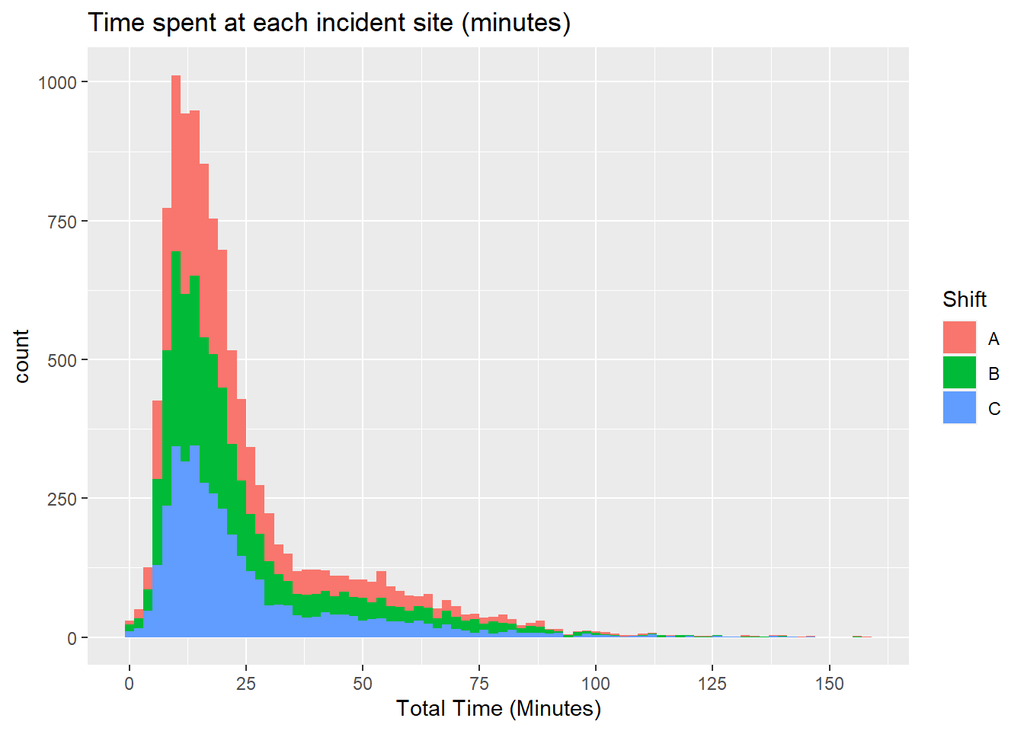

```r
# creation of histogram
ggplot(data = inc_time,
       mapping = aes( x= total_m, fill = Shift)) +
  geom_histogram(binwidth = 2) +
  labs(title = "Time spent at each incident site (minutes)", x = "Total Time (Minutes)") +
  scale_x_continuous(breaks = seq(0, 160, by=25))
```

## Conclusions

The most common incident description was “EMS call” (Emergency Medical Situation), but the second most frequent one was “EMS call where injured party has been transported by a non-fire service agency or left the scene prior to arrival”. The first description is used 11 times more than the second, leading us to believe that a lot of situation are grouped under this particular term. To be able to clearly see the frequency of the rest of the situations for which the fire department was called, we removed “EMS call” so that it would not overshadow.

For Months by Shift, there was slight increase in calls between July and October. For amount of time spent at each incident, most incidents take under 25 minutes. This is most likely because many of the responses are for medical emergencies. Once an ambulence arrives on the scene and the patient is taken away, the fire department is no longer needed. In terms of bias with our data set, this data set only pertains to the Burlington fire department, so our data set it would be more general to Vermont if other Vermont fire departments data were included.

## Limitations/recommendations

When it comes to the graphs we made and limitations, there is still a lot we could learn and improve using more efficient methods using r markdown.This would allow us to represent the graphs in more meaningful ways. We used leaflet for the first time for this project, and it felt like there are better ways to plot the data points.

A limitation in terms of the data set we were given was how the data was not descriptive with their labels, and we ran into issues where we were confused about what certain labels mean, and how to interpret the data. The information seemed to be specific to the Burlington Fire Department and was not available online. We tried to send an email to contact the makers of the data set, but never got a response. The Burlington Fire Department website was not very informative of information either.